# Assessment

AbdelRahman Hassane

2024-11-01

Library setup for assessment ahead.

```r
library(tidyverse)
library(janitor) #cleaning data
library(gt)  #tables
library(here) #directory structure
library(knitr) #generate reports
library(paletteer) #custome colour palettes to load for better data visualisation
library(sf) #load in sf object to create maps
library(lubridate) #converting time more easily
```

In this assessment, I will be looking at heart medication prescriptions in Scotland, specifically statins. There are 5 major statins prescribed in the NHS: atorvastatin,fluvastatin, pravastatin, rosuvastatin, simvastatin. Statins are effective medications for lowering the risk of heart disease or stroke as they reduce build up of LDL cholesterol, the bad kind, which can lead to artery narrowing and blockages. If left to accumulate, this could lead to a heart attack or stroke.

In the first section I will look at statins prescribed in each health board, viewing the most prescribed and the associated costs. I will be focusing on January 2024 data.

# Section 1

```r
#Import dataset for prescriptions in January 2024 from opendata, Public Health Scotland using the link below.
Jan2024prescrip <- read_csv("https://www.opendata.nhs.scot/dataset/84393984-14e9-4b0d-a797-b288db64d088/resource/d3eaaf84-0f3b-4fb8-9460-e33503095fbe/download/pitc202401.csv") %>%
  clean_names()
#Import health board names from opendata, Public Health Scotland using the link below.
HB_names <- read_csv("https://www.opendata.nhs.scot/dataset/9f942fdb-e59e-44f5-b534-d6e17229cc7b/resource/652ff726-e676-4a20-abda-435b98dd7bdc/download/hb14_hb19.csv")
#Import population dataset estimates for healthboards from opendata, Public Health Scotland using the link below.
HB_populations <- read_csv("https://www.opendata.nhs.scot/dataset/7f010430-6ce1-4813-b25c-f7f335bdc4dc/resource/27a72cc8-d6d8-430c-8b4f-3109a9ceadb1/download/hb2019_pop_est_14102024.csv") %>%
  clean_names()
```

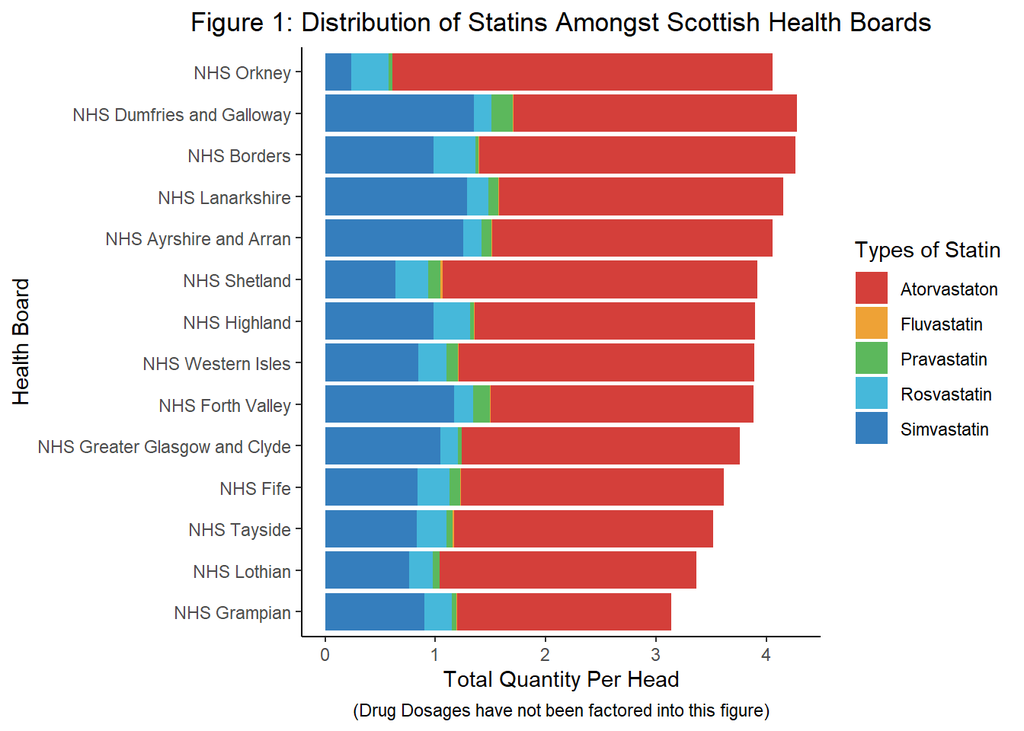

```r
#focusing on health board populations for year 2023 as its the most recent.
population_2023 <- HB_populations %>%
  filter(sex == 'All', year == 2023, !hb == 'S92000003') %>%
  select(year,hb,all_ages) %>%
  full_join(HB_names, by = c("hb" = "HB")) %>%
  filter(!is.na(all_ages)) %>%
  select(hb,HBName,all_ages) %>%
  rename(population2023 = all_ages)
#clean the January 2024 prescriptions dataset with a focus on statins.
Jan2024prescripclean <- Jan2024prescrip  %>%
#creating a new column for statins and simplifying different dosages into one name for simpler analysis.
  mutate(BNF_Drug_Statins = case_when(
    #renaming into lowercase for readability and easier to deal if filtered.
    str_detect(bnf_item_description, "^ATORVASTATIN") ~ "atorvastatin",
    str_detect(bnf_item_description, "^FLUVASTATIN") ~ "fluvastatin",
    str_detect(bnf_item_description, "^PRAVASTATIN") ~ "pravastatin",
    str_detect(bnf_item_description, "^ROSUVASTATIN") ~ "rosuvastatin",
    str_detect(bnf_item_description, "^SIMVASTATIN") ~ "simvastatin")) %>%
#joining health board names with the January 2024 prescription dataset.
  full_join(HB_names, by = c("hbt" = "HB")) %>%
  filter(bnf_item_description!="", !is.na(BNF_Drug_Statins)) %>%
  select(hbt,HBName,BNF_Drug_Statins,bnf_item_description,number_of_paid_items:gross_ingredient_cost) %>%
#joining 2023 population dataset with the January 2024 prescription dataset.
  full_join(population_2023, by = c("hbt" = "hb")) %>%
  group_by(HBName.x, BNF_Drug_Statins, population2023) %>%
  summarise(Total_quantity = sum(paid_quantity), Average_cost = mean(gross_ingredient_cost), Total_quantity_per_head = Total_quantity/mean(population2023))

#Plotting a stacked bar chart to allow for comparison of different health boards in one plot.
figure1 <- Jan2024prescripclean %>%
  ggplot(aes(x = Total_quantity_per_head, y = reorder(HBName.x, Total_quantity_per_head))) +
  geom_col(aes(fill = BNF_Drug_Statins)) +
  theme_classic() +
  scale_fill_paletteer_d("ggsci::default_locuszoom", name = "Types of Statin", labels = c("Atorvastaton","Fluvastatin","Pravastatin", "Rosvastatin", "Simvastatin")) +
  labs(x = "Total Quantity Per Head", y = "Health Board", title = "Figure 1: Distribution of Statins Amongst Scottish Health Boards", caption = "(Drug Dosages have not been factored into this figure)") +
  theme(plot.caption = element_text(hjust = 0.5), plot.title = element_text(hjust = 0.5))

figure1
```

From figure 1, Atorvastatin is the highest prescribed statin in all healthboards with NHS Orkney at a value of 3.44. It should be highlighted that Orkney does have a small population, 22,000, which is why it is larger than say NHS Greater Glasgow and Clyde with a population of 1,193,420. The lowest is fluvastatin in NHS Lanarkshire 0.0016 and this seems to be trend in other healthboards. Figure 1 also highlights that statin prescriptions are dominated by Atorvastatin, Simvastatin and Rosvastatin.

# Section 2

In this section, the focus will be on heart disease in Scottish health boards.

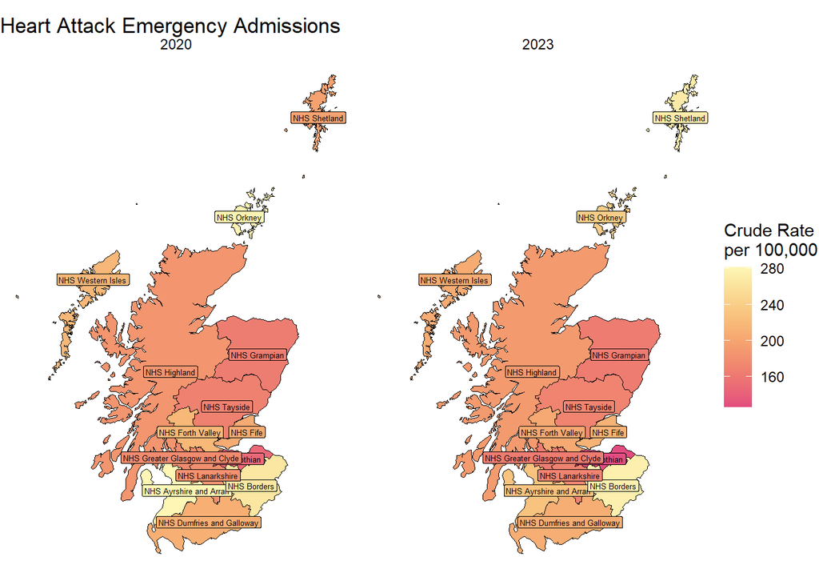

```r
#Import dataset for heart disease for Scottish health boards from Public Health Scotland
heart_disease_data <- read_csv("https://www.opendata.nhs.scot/dataset/0e17f3fc-9429-48aa-b1ba-2b7e55688253/resource/748e2065-b447-4b75-99bd-f17f26f3eaef/download/hd_activitybyhbr.csv") %>%
  clean_names()
#map data can be found from this link (need all 4 files to work): https://maps.gov.scot/ATOM/shapefiles/SG_NHS_HealthBoards_2019.zip
phs_map <- st_read(here("data" ,"NHS_healthboards_2019.shp")) %>%
  clean_names() %>%
  mutate(hb_name = paste("NHS",hb_name))
#focusing the dataset on emergency admissions with a focus a crude rate. crude rate is defined as the number of events occurring during a specified time multiplied by 100,000 of the population.
clean_heart_disease <- heart_disease_data %>%
  filter(financial_year %in% c("2019/20","2020/21","2021/22","2022/23"), sex == "All", age_group =="All", admission_type == "Emergency", !hbr %in% c("S92000003")) %>%
  select(financial_year,hbr,admission_type,diagnosis,crude_rate) %>%
  left_join(select(HB_names,HB,HBName), by = c("hbr" = "HB")) %>%
  select(financial_year,hbr,HBName,admission_type,diagnosis,crude_rate)

#joining the map dataset with the clean heart disease dataset for map plotting.
heart_disease_map <- clean_heart_disease %>%
  full_join(phs_map, by= c("hbr" = "hb_code")) %>%
  select(-hb_name) %>%
  #convert financial year character values into numeric as it is easier to work with.
  transform(financial_year = as.numeric(substring(financial_year, 1, 4)) + 1)

#plotting graph with a focus on heart attacks and emergency admissions in the 2020.
figure2 <- heart_disease_map %>%
  filter(financial_year %in% c(2020,2023), diagnosis =="Heart Attack") %>%
  #joining the heart disease sf map with the clean heart disease data converts it to a tibble. Need the state to R that geometry column exists otherwise error shows.
  ggplot(aes(geometry = geometry, fill = crude_rate))+
  geom_sf(color = "black", linewidth = 0.25) +
  geom_sf_label(aes(label = HBName), size = 1.75)+
  theme_void()+
  facet_wrap(.~financial_year)+
  scale_fill_paletteer_c("grDevices::PinkYl")+
  labs(title = "Heart Attack Emergency Admissions", fill = "Crude Rate \nper 100,000", plot.title = element_text(hjust = 0.5))

figure2
```

From figure 2 the crude rate of heart attack emergency admissions are plotted across years 2020 and 2023. It is important that although NHS Greater Glasgow and Clyde, NHS Lanarkshire and NHS Lothian have the 3 largest population the crude rate is low which can be misinterpreted as good. From 2020 to 2023 the changes in heart attack emergency admissions have decreased slightly with some outliers like NHS Shetland and NHS Ayrshire and Arran.Additionally, there a lot of confounding factors to consider like hospital access, population size or the type of medication taken which could explain the change in crude rate. Therefore, the reduction in crude rate cannot be solely contributed to statin uptake by the general populus although it does highlight that heart attacks have reduced from 2020 to 2023.

# Section 3

This section will look more at changes to average costs of statins and quanity prescribed per head from 2020 to 2023. The focus will be on NHS Greater Glasgow and Clyde as it has the largest population.

```r
#Import dataset for prescriptions in January 2020 until 2023 from opendata, Public Health Scotland using the link below.
Jan2023prescrip <- read_csv("https://www.opendata.nhs.scot/dataset/84393984-14e9-4b0d-a797-b288db64d088/resource/6caa7144-f0e4-4ab0-b9e4-8fa10c8edf1c/download/pitc202301.csv") %>%
  clean_names()
Jan2022prescrip <- read_csv("https://www.opendata.nhs.scot/dataset/84393984-14e9-4b0d-a797-b288db64d088/resource/53a53d61-3b3b-4a12-888b-a788ce13db9c/download/pitc202201.csv") %>%
  clean_names()
Jan2021prescrip <- read_csv("https://www.opendata.nhs.scot/dataset/84393984-14e9-4b0d-a797-b288db64d088/resource/7722a6e6-a6b6-49ec-aa63-fdc4bc727f05/download/pitc202101.csv") %>%
  clean_names()
Jan2020prescrip <- read_csv("https://www.opendata.nhs.scot/dataset/84393984-14e9-4b0d-a797-b288db64d088/resource/e5c841f2-3e16-428b-97db-0798ec7a5fb4/download/pitc202001.csv") %>%
  clean_names()
```

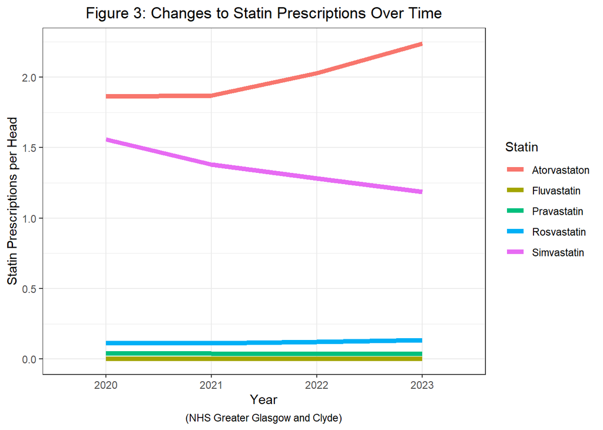

```r
#ceate a dataset that combines all previous years to set up for the table
population_2020_2023 <- HB_populations %>%
  #S92000003 NHS Scotland needs to be removed from data and filtering out for years of interest.
  filter(sex == 'All', year %in% c(2020,2021,2022,2023), !hb == 'S92000003') %>%
  select(year,hb,all_ages) %>%
  full_join(HB_names, by = c("hb" = "HB")) %>%
  select(hb,HBName,year,all_ages) %>%
  rename(population = all_ages)%>%
  filter(!is.na(population)) %>%
  #converting the year into a character column makes it easier when dealing with gt table.
  mutate_at("year", as.character)

#combine all January prescription datasets into 1 table as they all have the same columns.
statin4years <- bind_rows(Jan2023prescrip,Jan2022prescrip,Jan2021prescrip,Jan2020prescrip) %>%
  select(hbt,paid_date_month,bnf_item_description, number_of_paid_items:gross_ingredient_cost) %>%
  mutate(BNF_Drug_Statins = case_when(
    str_detect(bnf_item_description, "^ATORVASTATIN") ~ "atorvastatin",
    str_detect(bnf_item_description, "^FLUVASTATIN") ~ "fluvastatin",
    str_detect(bnf_item_description, "^PRAVASTATIN") ~ "pravastatin",
    str_detect(bnf_item_description, "^ROSUVASTATIN") ~ "rosuvastatin",
    str_detect(bnf_item_description, "^SIMVASTATIN") ~ "simvastatin")) %>%
  mutate(paid_date_month = case_when(
    str_detect(paid_date_month,"2023")~"2023",
    str_detect(paid_date_month,"2022")~"2022",
    str_detect(paid_date_month,"2021")~"2021",
    str_detect(paid_date_month,"2020")~"2020",)) %>%
  filter(bnf_item_description!="", !is.na(BNF_Drug_Statins)) %>%
  select(-bnf_item_description) %>%
  full_join(HB_names, by = c("hbt" = "HB")) %>%
  select(hbt,HBName,paid_date_month,BNF_Drug_Statins, number_of_paid_items:gross_ingredient_cost) %>%
  group_by(HBName,paid_date_month,BNF_Drug_Statins) %>%
  summarise(Total_paid_quantity = sum(paid_quantity), Average_cost = mean(gross_ingredient_cost))

#setting up object for gt table creation.
clean_statin4years_table <- statin4years %>%
  full_join(population_2020_2023, by = c("HBName", "paid_date_month"="year")) %>%
  filter(!is.na(population)) %>%
  select(-hb) %>%
  mutate(quantity_per_head = (Total_paid_quantity/mean(population))) %>%
  filter(HBName == "NHS Greater Glasgow and Clyde") %>%
  select(HBName,paid_date_month,BNF_Drug_Statins,quantity_per_head,Average_cost) %>%
  #pivot wider was used to convert the table into an easy to read format.
  pivot_wider(names_from = paid_date_month, values_from = quantity_per_head:Average_cost) %>%
  #columns needed to be reordered to prepare for table creation. numbers were used as the column names alternated every 2 columns.
  select(HBName,BNF_Drug_Statins, 3,7,4,8,5,9,6,10) %>%
  gt() %>%
  #create table title.
    tab_header( title = "Table 1: Changes to Statin Prescriptions Over the Years",
                subtitle = "From 2020 to 2023 focusing on January" ) %>%
  #rename statins with capital.
  text_case_match(
    "atorvastatin" ~ "Atorvastatin",
    "fluvastatin" ~ "Fluvastatin",
    "pravastatin" ~ "Pravastatin",
    "rosuvastatin" ~ "Rosuvastatin",
    "simvastatin" ~ "Simvastatin") %>%
  #rename column labels
  cols_label(
    BNF_Drug_Statins = "Statin Type",
    starts_with("quantity") ~ "Quantity per Head",
    starts_with("Average") ~ "Average Cost",
    starts_with("BNF") ~ "") %>%
  #sub title were used to make the columns more readable.
  tab_spanner( label = "2020",
               columns = ends_with("2020")) %>%
  tab_spanner( label = "2021",
               columns = ends_with("2021")) %>%
  tab_spanner( label = "2022",
               columns = ends_with("2022")) %>%
  tab_spanner( label = "2023",
               columns = ends_with("2023")) %>%
  #introduce currency symbol for average cost columns.
  fmt_currency(
    columns = starts_with("Average"),
    decimals = 2,
    currency = "GBP") %>%
  #clean the numbers to make it more readable.
  fmt_number(
    columns = starts_with("quantity"),
    decimals = 3) %>%
  opt_stylize(style = 6, color = "blue")

figure3 <- statin4years %>%
  full_join(population_2020_2023, by = c("HBName", "paid_date_month"="year")) %>%
  filter(!is.na(population)) %>%
  select(-hb) %>%
  mutate(quantity_per_head = (Total_paid_quantity/mean(population))) %>%
  filter(HBName %in% c("NHS Greater Glasgow and Clyde")) %>%
  ggplot(aes(x = paid_date_month, y = quantity_per_head))+
  geom_line(aes(group = BNF_Drug_Statins, color = BNF_Drug_Statins), linewidth = 1.8) +
  theme_bw() +
  scale_color_discrete(labels = c("Atorvastaton","Fluvastatin","Pravastatin", "Rosvastatin", "Simvastatin"))+
  labs(x = "Year", y = "Statin Prescriptions per Head", title = "Figure 3: Changes to Statin Prescriptions Over Time",caption = "(NHS Greater Glasgow and Clyde)", color = "Statin")+
  theme(plot.caption = element_text(hjust = 0.5), plot.title = element_text(hjust = 0.5))

figure3
```

```r
clean_statin4years_table
```

Table 1: Changes to Statin Prescriptions Over the Years

From 2020 to 2023 focusing on January

|  | 2020 Quantity per Head | 2020 Average Cost | 2021 Quantity per Head | 2021 Average Cost | 2022 Quantity per Head | 2022 Average Cost | 2023 Quantity per Head | 2023 Average Cost |
| --- | --- | --- | --- | --- | --- | --- | --- | --- |
| NHS Greater Glasgow and Clyde |  |  |  |  |  |  |  |  |
| Atorvastatin | 1.864 | £115.21 | 1.871 | £116.04 | 2.028 | £121.45 | 2.239 | £109.85 |
| Fluvastatin | 0.003 | £10.71 | 0.003 | £9.42 | 0.003 | £10.04 | 0.003 | £9.93 |
| Pravastatin | 0.043 | £7.26 | 0.039 | £6.71 | 0.036 | £6.31 | 0.037 | £5.56 |
| Rosuvastatin | 0.115 | £10.12 | 0.112 | £11.19 | 0.122 | £8.06 | 0.133 | £10.06 |
| Simvastatin | 1.557 | £85.01 | 1.380 | £74.43 | 1.282 | £71.48 | 1.187 | £75.25 |

Figure 3 was plotted to highlight that quantity per head columns in table 1 to allow for easier visualization. From figure 3, Fluvastatin has been prescribed the lowest with minimal changes throughout the years whilst Atorvastatin remains the highest prescribed and increasing significantly since 2021. Simvastatin follows a similar trajectory but mirrorred. Dawn Connely highlights that Atorvastatin had lost its patent since 2012 and the cost of the NHS prescribing it dropped from £311 million to £42 million and Simvastatin does have side effect of myopathy, muscle weakness. Furthermore as NICE recommends Atorvastatin for first line of treatment for patients with high cholesteroh. Both previous enforce the popularity of Atorvastatin over other statins. Although the average cost columns in table 1 highlight a higher average gross ingredient cost for Atorvastatin compared to others, interestingly the average cost drops by 4.65% whilst Simvastatin drops by 11.4%. Although the remaining 3 statins maintain a similar average cost across from 2020 to 2023 they are prescribed significantly less. it is more cost effective and with less side effects when compared to other statins.

# References

1. The Pharmaceutical Journal, PJ, September 2018, Vol 301, No 7917;301(7917):DOI:10.1211/PJ.2018.20205512